# starter_pack_brazil

# 1 Starter Pack: Flood risk in Porto Alegre, Brazil

This contains the code and documentation for a flood risk analysis for Porto Alegre in Rio Grande do Sul, Brazil. The notebooks explore impacts on housing, businesses and schools.

## 1.1 Setup

- Clone this repository to your local machine, or download a ZIP of this folder by clicking the green ‘Code’ dropdown above followed by the ‘Download ZIP’ button.
- Set up a virtual environment with containing CLIMADA. The CLIMADA [Getting Started](https://climada-python.readthedocs.io/en/stable/getting-started/index.html) guide explains how.
- If necessary, set up Jupyter notebooks. You can look up how do this at a system level, which allows the functionality to be reused across environments, or on the command line you can activate your virtual environment (covered in the guide linked above) and run `mamba install jupyter` (you can replace `mamba` with `conda` or with the relevant installation instruction for your environment manager.)
- Either: Open the folder in your preferred development environment and activate the virtual environment. OR: from the command line activate your virtual environment (covered in the guide linked above) and run `jupyter notebook`.
- Run these notebooks. You may need to edit the filepaths at the start of each file. Throughout the notebooks parameters can be changed, and datasets can be modified and improved. We encourage you to explore.

## 1.2 Structure

- The data/ folder contains all the required input data
- The notebooks/ folder goes through the risk analysis step by step:
  - 01_entity_exposures.ipynb – Mapping the exposed assets
  - 02_entity_impact_functions.ipynb – Visualising the impact functions
  - 03_hazard.ipynb – Mapping the hazard data
  - 04_uncalibrated_risk.ipynb – Running a risk calculation with the uncalibrated data
  - 05_observations.ipynb - Examine the observations data
  - 06a_calibration_schools.ipynb - Calibrating impact functions for schools
  - 09_costbenefit.ipynb - Running a cost-benefit assessment for adaptation measures
- The starter_pack_brazil.html file contains these notebooks and their output in a single HTML file

## 1.3 Contributing

This analysis is intended to support teaching materials and is still under development. If any of the code doesn’t work, if something could be added to improve the analysis, or if something could be explained more clearly, please let us know. You can do this by creating a GitHub Issue, or by contacting us by email.

# 2 Exposed assets

In this notebook we read Entity files for Porto Alegre, Brazil and visualize the Exposures data for housing, schools and businesses.

## 2.1 Read Exposures from Entity files

The `climada.entity` package provides the tools to interact with Entity files.

Exposure data must be stored in the *first sheet* of the Excel workbook, called ‘assets’ by convention. The exposure data is stored in the Entity’s `exposures` attribute, and is an instance of CLIMADA’s [Exposures](https://climada-python.readthedocs.io/en/v6.1.0/user-guide/climada_entity_Exposures.html) class. They don’t need to be financial: the units are specified within the file.

Let’s set up our project folders and read in the file(s). This notebook (and the following notebooks) is set up to explore a list of different Entity files, each containing a different asset type.

**NOTE:** You can also create Exposures objects from pandas DataFrames, geopandas GeoDataframes, other Excel files, CSVs, HDF5 files, and raster (e.g. TIF) data. See the [CLIMADA User Guide](https://climada-python.readthedocs.io/en/v6.1.0/user-guide/climada_entity_Exposures.html) for the different ways to do this.

```python
from climada.entity import Entity
from pathlib import Path

# Set the directory where our Entity files are located
ENTITY_DIR = "../data/entity_files_uncalibrated/"
# Give a list of Entity file names (so we can examine more than one file if we want)
ENTITY_FILES = ["Porto_Alegre_BRAZIL_Entity_Floods_Residential.xlsx", "Porto_Alegre_BRAZIL_Entity_Floods_Companies.xlsx", "Porto_Alegre_BRAZIL_Entity_Floods_Schools.xlsx"]

entity_filepaths = [Path(ENTITY_DIR) / filename for filename in ENTITY_FILES]
```

```python
# Read in the files
entity_list = []
for filepath in entity_filepaths:
    print(f"Reading {filepath.name}...")
    entity = Entity.from_excel(filepath)

    # After reading in the file, it is a good idea to set additional properties of the Exposures object

    # ref_year:
    # We can optionally set a reference year for the entity, which describes the year (past, present or future) that the data represent.
    # This is required when the Exposures are used in a cost-benefit analysis, comparing risk at two different points in time.
    entity.exposures.ref_year = 2026

    # value_unit:
    # The unit of the exposure values. This needs to be specified but will be read from the Excel file after the next release
    entity.exposures.value_unit = "USD"

    # description:
    # Optional – used for creating plot titles
    entity.exposures.description = f"Exposures from {filepath.name}"

    entity_list.append(entity)


# We can then store the exposures in their own list by accessing the `exposures` property:
exposures_list = [entity.exposures for entity in entity_list]
```

```
Reading Porto_Alegre_BRAZIL_Entity_Floods_Residential.xlsx...
Reading Porto_Alegre_BRAZIL_Entity_Floods_Companies.xlsx...
Reading Porto_Alegre_BRAZIL_Entity_Floods_Schools.xlsx...
```

## 2.2 Exposures properties

The Excel sheets we just read in are stored in the `Exposures.gdf` (=‘GeoDataFrame’) attribute. We can print some summary information about the Exposures we’re working with:

```python
from IPython.display import display

for exp in exposures_list:
    print("")
    print(exp.description)
    print(f"- The Exposures consists of {len(exp.gdf)} points")
    print(f"- Their total value is {exp.gdf['value'].sum():,.0f} {exp.value_unit}")
    print(f"- The points lie between latitudes {exp.latitude.min():.2f} and {exp.latitude.max():.2f}")
    print(f"- The points lie between longitudes {exp.longitude.min():.2f} and {exp.longitude.max():.2f}")
    # If there is region information
    if "region_id" in exp.gdf.columns:
        print(f" -The exposure contains {exp.gdf['region_id'].nunique()} region id(s)")
    # If there is category information
    if "category_id" in exp.gdf.columns:
        print(f"- The exposure contains {exp.gdf['category_id'].nunique()} category id(s)")
    # Find information about impact functions – the column names for these depend on the hazard type
    for col in exp.gdf.columns:
        if col.startswith("impf_"):
            print(f"- The exposure uses {exp.gdf[col].nunique()} impact function(s) (column: '{col}')")

for exp in exposures_list:
    print('\n' + exp.description + ' (first 5 rows)')
    display(exp.gdf.head())
```

```
Exposures from Porto_Alegre_BRAZIL_Entity_Floods_Residential.xlsx
- The Exposures consists of 20187 points
- Their total value is 69,311,916,748 USD
- The points lie between latitudes -30.26 and -29.94
- The points lie between longitudes -51.29 and -51.01
 -The exposure contains 1 region id(s)
- The exposure contains 1 category id(s)
- The exposure uses 1 impact function(s) (column: 'impf_FL')

Exposures from Porto_Alegre_BRAZIL_Entity_Floods_Companies.xlsx
- The Exposures consists of 4366 points
- Their total value is 3,655,929,050 USD
- The points lie between latitudes -30.24 and -29.97
- The points lie between longitudes -51.27 and -51.08
 -The exposure contains 1 region id(s)
- The exposure contains 1 category id(s)
- The exposure uses 1 impact function(s) (column: 'impf_FL')

Exposures from Porto_Alegre_BRAZIL_Entity_Floods_Schools.xlsx
- The Exposures consists of 122 points
- Their total value is 305,000,000 USD
- The points lie between latitudes -30.24 and -29.97
- The points lie between longitudes -51.26 and -51.09
 -The exposure contains 1 region id(s)
- The exposure contains 1 category id(s)
- The exposure uses 1 impact function(s) (column: 'impf_FL')

Exposures from Porto_Alegre_BRAZIL_Entity_Floods_Residential.xlsx (first 5 rows)
```

|  | category_id | region_id | value | count | deductible | cover | impf_FL | Value_unit | geometry |
| --- | --- | --- | --- | --- | --- | --- | --- | --- | --- |
| 0 | 1 | 1 | 181864 | 2 | NaN | NaN | 101 | USD | POINT (-51.28865 -29.96417) |
| 1 | 1 | 1 | 90932 | 1 | NaN | NaN | 101 | USD | POINT (-51.28862 -29.95153) |
| 2 | 1 | 1 | 181864 | 2 | NaN | NaN | 101 | USD | POINT (-51.28762 -29.96417) |
| 3 | 1 | 1 | 272796 | 3 | NaN | NaN | 101 | USD | POINT (-51.28037 -29.96870) |
| 4 | 1 | 1 | 90932 | 1 | NaN | NaN | 101 | USD | POINT (-51.27934 -29.97051) |

```
Exposures from Porto_Alegre_BRAZIL_Entity_Floods_Companies.xlsx (first 5 rows)
```

|  | category_id | region_id | value | count | deductible | cover | impf_FL | Value_unit | geometry |
| --- | --- | --- | --- | --- | --- | --- | --- | --- | --- |
| 0 | 1 | 1 | 375275 | 1 | NaN | NaN | 201 | USD | POINT (-51.26744 -29.98953) |
| 1 | 1 | 1 | 375275 | 1 | NaN | NaN | 201 | USD | POINT (-51.26559 -29.99387) |
| 2 | 1 | 1 | 750550 | 2 | NaN | NaN | 201 | USD | POINT (-51.26556 -30.10108) |
| 3 | 1 | 1 | 375275 | 1 | NaN | NaN | 201 | USD | POINT (-51.26311 -29.99847) |
| 4 | 1 | 1 | 375275 | 1 | NaN | NaN | 201 | USD | POINT (-51.26253 -30.01418) |

```
Exposures from Porto_Alegre_BRAZIL_Entity_Floods_Schools.xlsx (first 5 rows)
```

|  | category_id | region_id | value | count | deductible | cover | impf_FL | Value_unit | geometry |
| --- | --- | --- | --- | --- | --- | --- | --- | --- | --- |
| 0 | 1 | 1 | 2500000 | 1 | NaN | NaN | 301 | USD | POINT (-51.12157 -29.98418) |
| 1 | 1 | 1 | 2500000 | 1 | NaN | NaN | 301 | USD | POINT (-51.19623 -29.97862) |
| 2 | 1 | 1 | 2500000 | 1 | NaN | NaN | 301 | USD | POINT (-51.11991 -29.98967) |
| 3 | 1 | 1 | 2500000 | 1 | NaN | NaN | 301 | USD | POINT (-51.11557 -29.98551) |
| 4 | 1 | 1 | 2500000 | 1 | NaN | NaN | 301 | USD | POINT (-51.13710 -29.97849) |

Points worth noting about the `Entity.exposures` geodataframe: - The original latitude and longitude columns have been converted to a ‘geometry’ column. You can still access the raw values with the `Exposures.latitude` and `Exposures.longitude` properties - The deductible and cover columns are used when asset-level insurance is modelled as an adaptation measure – for now they should be left blank in the Excel workbook - Each exposure point is acted on by an impact function. This is defined here in the ‘impf_FL’ column. The last two letters are used to specify the hazard type (here: flood) and is used in matching between datasets. A column ‘impf_’ with no hazard type is also valid, and will match to any hazard type.

## 2.3 Visualize the Exposures: points on a map

There are a few ways to visualize an Exposures object. Simplest is to plot them as points on a map with `Exposures.plot_basemap`.

In the plots below we can see the different ways that the Exposures were created: - The Residential exposures come from a gridded dataset of housing information, and covers the whole Porto Alegre region - The Schools and Companies exposures come from a database of affected locations, and are limited to areas that were impacted by flooding.

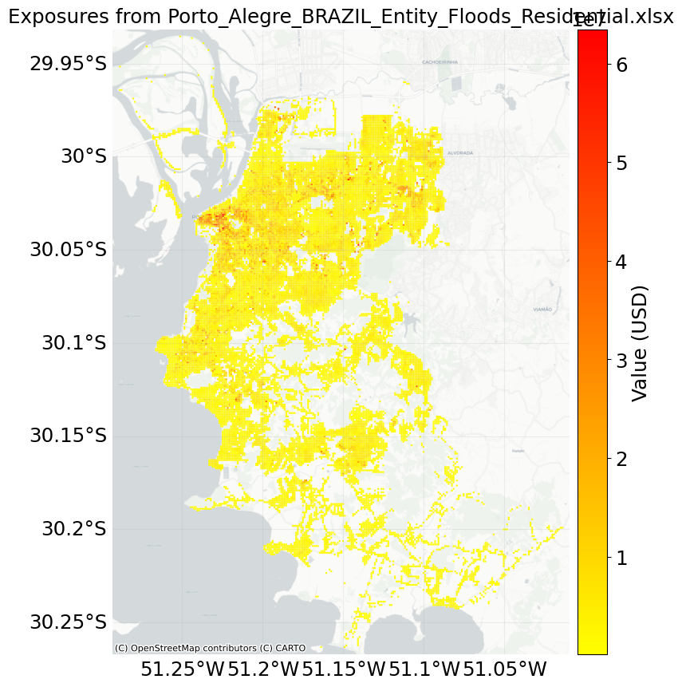

png

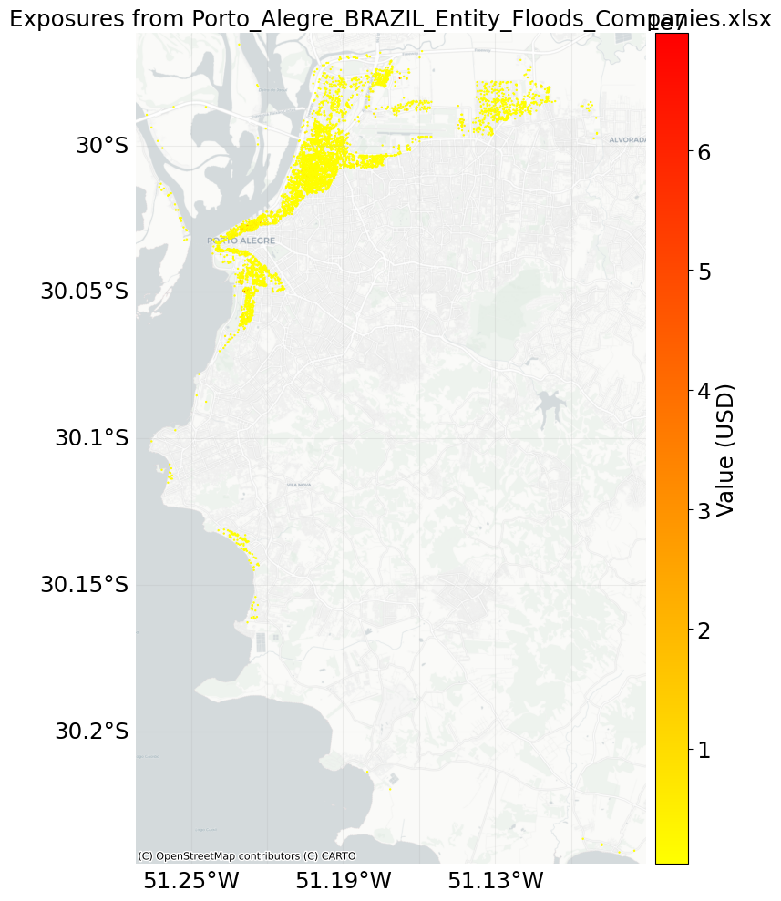

png

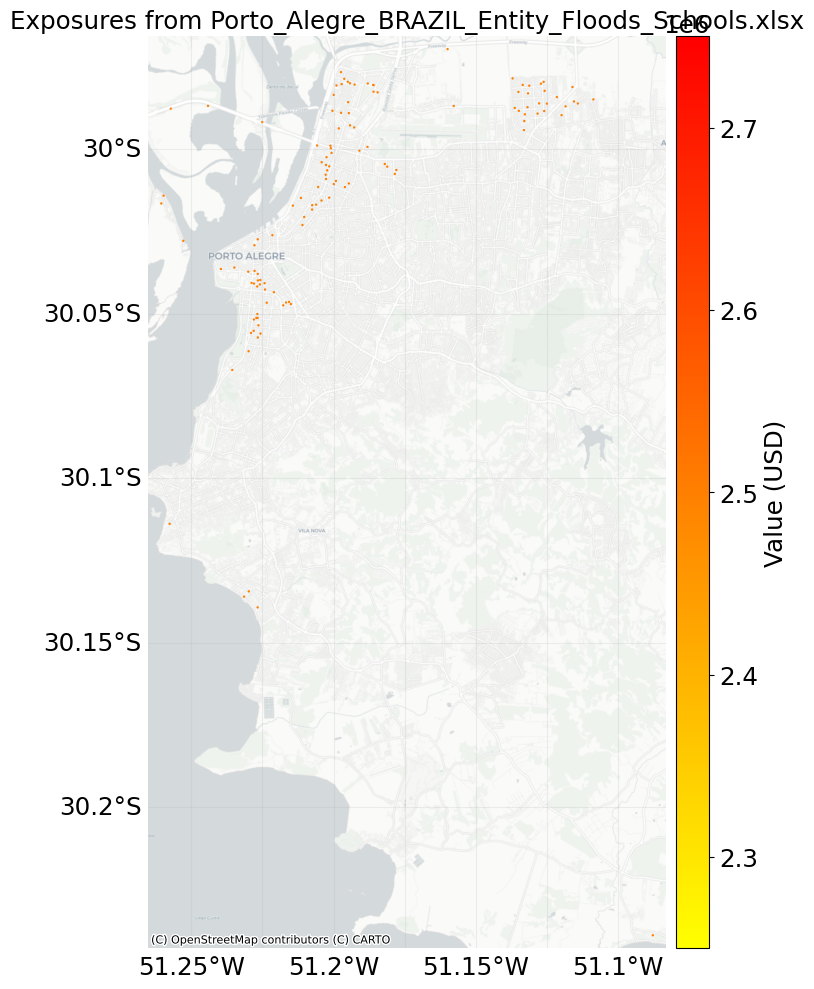

png

```python
%matplotlib inline
import contextily as ctx

for exp in exposures_list:
    exp.plot_basemap(
        title=exp.description,   # Title for the map. This is the default value.
        ignore_zero=False,       # Whether to plot points with zero value
        buffer=500,              # Add a buffer around the points to show a larger map region (measured in meters)
        s=0.5,                   # The size of point markers on the plot
        zoom=13,                 # The detail level of the map. 6 is good for a large country. 8 is good for a state or region. 13 for a city. 15 for a municipality.
        url=ctx.providers.CartoDB.Positron,
                                 # Set a basemap using contextily – here we use CartoDB's Positron which gives a pale, monochrome basemap
                                 #     Another good option is OpenStreetMap's Mapnik (`ctx.providers.OpenStreetMap.Mapnik`)
                                 #     ... this gives a more colourful basemap
                                 #     See all options at: https://xyzservices.readthedocs.io/en/stable/gallery.html
        pop_name=False,          # Add the names of populated places to the map – often not necessary when you have a basemap
        vmax=None,               # Set the maximum value for the colour scale – use this if you want a consistent scale across multiple plots.
        cmap="autumn_r",         # Colour scheme to use for the points. See https://matplotlib.org/stable/tutorials/colors/colormaps.html for options.
        figsize=(8, 10)          # Dimensions of the output figure
    )
```

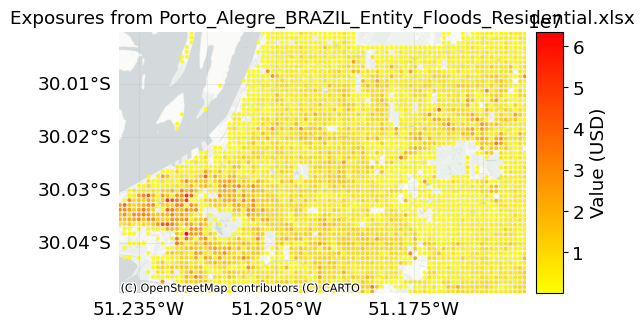

png

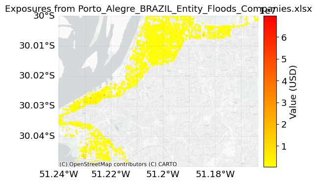

png

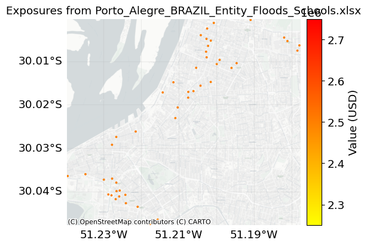

png

```python
# Let's zoom in and plot a smaller area:

sample_region = (-51.24, -51.15, -30.05, -30.00)  # (min_lon, max_lon, min_lat, max_lat)
lon_min, lon_max, lat_min, lat_max = sample_region

for exp in exposures_list:
    exp_zoom = exp.copy(deep=True)
    exp_zoom.set_gdf(exp_zoom.gdf.cx[lon_min:lon_max, lat_min:lat_max])
    exp_zoom.plot_basemap(
        title=exp_zoom.description,   # Title for the map. This is the default value.
        ignore_zero=False,       # Whether to plot points with zero value
        buffer=30,               # Add a buffer around the points to show a larger map region (measured in meters)
        s=3,                     # The size of point markers on the plot
        zoom=16,                 # The detail level of the map. 6 is good for a large country. 8 is good for a state or region. 13 for a city. 15 for a municipality.
        pop_name=False,          # Add the names of populated places to the map – often not necessary when you have a basemap
        vmax=None,               # Set the maximum value for the colour scale – use this if you want a consistent scheme across multiple plots.
        cmap="autumn_r",         # Colour scheme to use for the points. See https://matplotlib.org/stable/tutorials/colors/colormaps.html for options.
        figsize=(6, 8)           # Dimensions of the output figure
    )
```

## 2.4 Visualize Exposures: hexmap

When there are a lot of Exposure points, plotting them all on a map can obscure information because they overlap too much.

In this case aggregating the exposures to create a hexmap is useful. You can specify whether you’d like each hex to display the sum (most common) of the points within it, or some other function, e.g. mean or max.

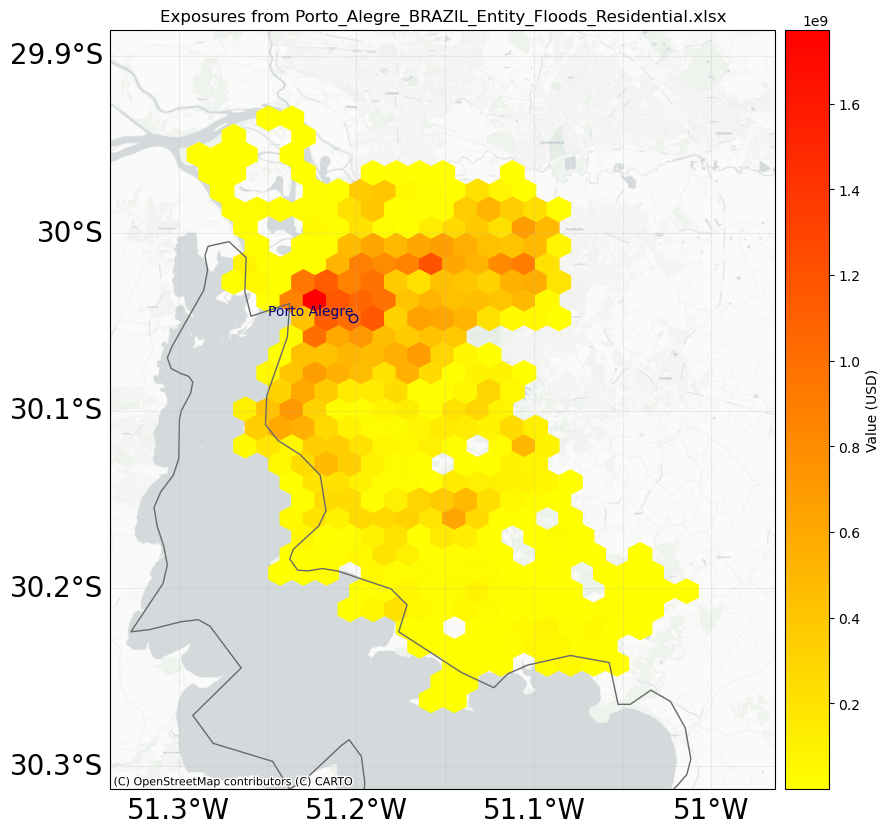

png

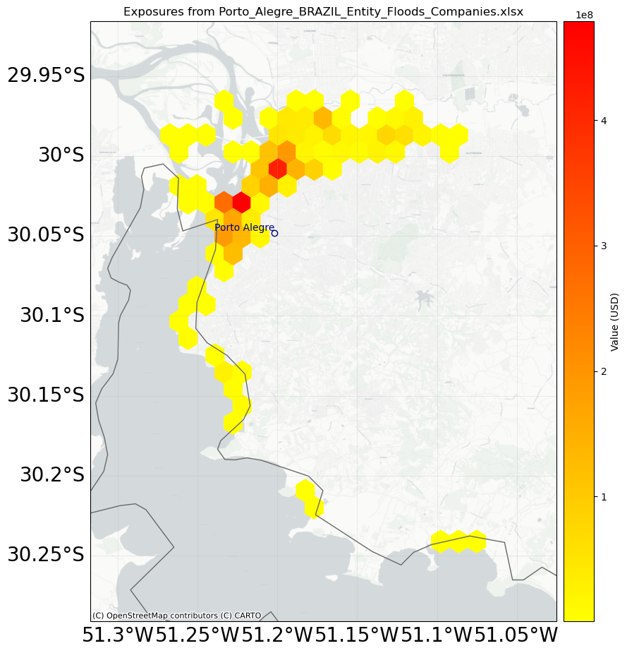

png

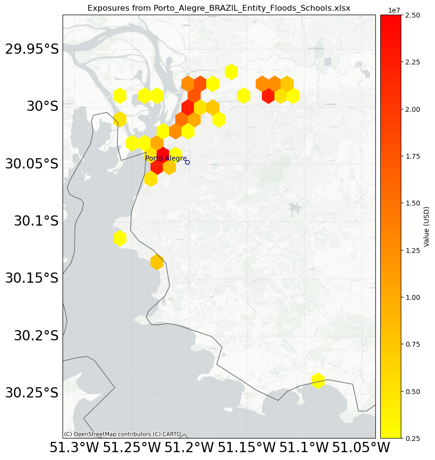

png

```python
import numpy as np
import cartopy.crs as ccrs
from climada.util import plot as u_plot

for exp in exposures_list:
    # (Optional) Set the number of bins in each direction of the map
    bin_size = 0.02  # The size of the hexagonal bins in units of latitude and longitude
    xmin, xmax = exp.longitude.min(), exp.longitude.max()
    ymin, ymax = exp.latitude.min(), exp.latitude.max()
    dim_x = int((xmax - xmin) / bin_size) + 8  # The binning isn't perfect, so we manually adjust this to make it look better
    dim_y = int((ymax - ymin) / bin_size)

    # (Optional) standardise projections and create a basemap
    proj_plot = ccrs.PlateCarree(central_longitude=0.5 * (xmin + xmax))  # Setting a central longitude allows us to plot data that crosses the 180 degree antimeridian – not so relevant here
    _, axis, fontsize = u_plot.make_map(
        proj=proj_plot, figsize=(9, 13), adapt_fontsize=True
    )

    # Plot the hexbin
    axis = exp.plot_hexbin(
        ignore_zero=True,         # Whether to plot points with zero value
        pop_name=True,            # Add the names of populated places to the map
        buffer=0.05,              # Add a buffer around the points to show a larger map region (measured in units of latitude and longitude) (different from `plot_basemap`!)
        axis=axis,
        figsize=(8, 10),
        title=exp.description,    # Title for the map. This is the default value.
        reduce_C_function=np.sum, # How to aggregate the individual exposure points to the hexagonal bins. They are summed like this by default, but you could also use np.mean, np.median, etc.
        gridsize=(dim_x, dim_y),              # The number of hexagons to use in the x-direction across the generated map
        cmap="autumn_r",          # Colour scheme to use for the points. See https://matplotlib.org/stable/tutorials/colors/colormaps.html for options.
    )
    # Add a basemap – see the previous cell for details on how to customize this
    ctx.add_basemap(axis, zoom=14, source=ctx.providers.CartoDB.Positron, origin="upper", crs=proj_plot)
```

# 3 Impact functions

In this notebook we read Entity files for Porto Alegre, Brazil and plot (uncalibrated) Impact Functions for housing, businesses and schools.

## 3.1 Impact functions from the Entity file

Impact functions describe the relationship between the intensity of a hazard and its effect on your chosen exposure.

They are stored in the Entity Excel workbook in the ‘impact_functions’ sheet. The sheet can specify any number of impact functions. Each function is read in and stored in an `ImpactFunc` object, which are then grouped into an `ImpactFuncSet` object and stored in the `Entity`’s `impact_funcs` attribute.

All of these classes are part of CLIMADA’s `climada.entity` package.

There are two ways to create impact functions for an analysis: from an Entity file, or programatically by constructing an `ImpactFunc` object. This notebook reads from a file. For more information on Impact Functions, see the [CLIMADA User Guide](https://climada-python.readthedocs.io/en/stable/user-guide/climada_entity_ImpactFuncSet.html).

Let’s read in the Entity files and visualize the functions:

```python
from pathlib import Path

# Set the directory where our Entity files are located
ENTITY_DIR = "../data/entity_files_uncalibrated/"
# Give a list of Entity file names (so we can examine more than one file if we want)
ENTITY_FILES = ["Porto_Alegre_BRAZIL_Entity_Floods_Residential.xlsx", "Porto_Alegre_BRAZIL_Entity_Floods_Companies.xlsx", "Porto_Alegre_BRAZIL_Entity_Floods_Schools.xlsx"]

entity_filepaths = [Path(ENTITY_DIR) / filename for filename in ENTITY_FILES]
```

```python
from climada.entity import Entity

# Read in the files
entity_list = []
for filepath in entity_filepaths:
    print(f"Reading {filepath.name}...")
    entity = Entity.from_excel(filepath)
    entity.exposures.ref_year = 2026    # Set reference year
    entity.exposures.value_unit = "USD"
    entity.exposures.description = f"Exposures from {filepath.name}"
    entity_list.append(entity)
```

```
Reading Porto_Alegre_BRAZIL_Entity_Floods_Residential.xlsx...
Reading Porto_Alegre_BRAZIL_Entity_Floods_Companies.xlsx...
Reading Porto_Alegre_BRAZIL_Entity_Floods_Schools.xlsx...
```

```python
HAZ_TYPE = "FL"  # This is the code we use to indicate impact functions for floods in Impact Functions

# We can then store the impact function sets in their own list:
impf_set_list = [entity.impact_funcs for entity in entity_list]

for filename, impf_set in zip(ENTITY_FILES, impf_set_list):
    print(f"There are {impf_set.size()} impact functions in {filename} with IDs {impf_set.get_ids(haz_type=HAZ_TYPE)}.")
```

```
There are 2 impact functions in Porto_Alegre_BRAZIL_Entity_Floods_Residential.xlsx with IDs [101, 102].
There are 2 impact functions in Porto_Alegre_BRAZIL_Entity_Floods_Companies.xlsx with IDs [201, 202].
There are 2 impact functions in Porto_Alegre_BRAZIL_Entity_Floods_Schools.xlsx with IDs [301, 302].
```

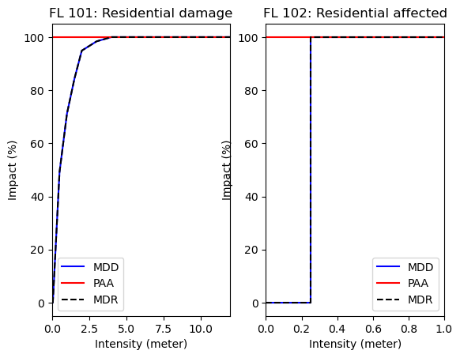

png

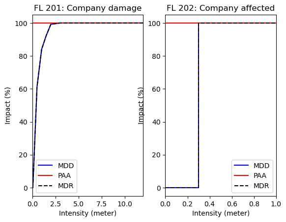

png

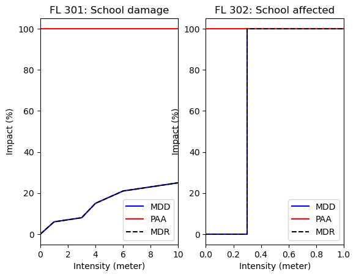

png

```python
# Visualize the impact functions
# (this can be quite messy when you have multiple functions)
for impf_set in impf_set_list:
    impf_set.plot(fun_id=None)  # Specify fun_id to plot a single function
```

An impact function is defined by the following properties:

```python
# Choose an example impact function to examine in more detail
example_impf_set = impf_set_list[0]
example_fun_ids = example_impf_set.get_ids(haz_type=HAZ_TYPE)
example_impf = example_impf_set.get_func(haz_type=HAZ_TYPE,fun_id=example_fun_ids[0])

print(f"Details from an example impact function:")
# The function ID
print(f"Function ID: {example_impf.id}")
# The hazard type ('None' is acceptable)
print(f"Hazard type: {example_impf.haz_type}")
# The intensity unit
print(f"Intensity unit: {example_impf.intensity_unit}")
# The intensity values for which damage is defined
print(f"Intensity values: {example_impf.intensity}")
# The mean damage degree values: the average damage experienced by assets at these hazard intensities
print(f"Mean damage degree values: {example_impf.mdd}")
# The percentage of assets affected: the average percentage of assets affected by this intensity of hazard at a single location
print(f"Percentage of assets affected: {example_impf.paa}")
# The name (optionally)
print(f"Name: {example_impf.name}")
```

```
Details from an example impact function:
Function ID: 101
Hazard type: FL
Intensity unit: meter
Intensity values: [ 0.    0.05  0.5   1.    1.5   2.    3.    4.    5.    6.   12.  ]
Mean damage degree values: [0.    0.    0.491 0.711 0.842 0.949 0.984 1.    1.    1.    1.   ]
Percentage of assets affected: [1 1 1 1 1 1 1 1 1 1 1]
Name: Residential damage
```

# 4 Hazard

In this notebook we read in Hazard data from a raster file, break down its properties and plot it.

CLIMADA describes hazards as one or more (and maybe thousands) of event footprints in a file. Each event in a Hazard object is a geospatial footprint – usually an event footprint (e.g. a historical flood depth reconstruction, or a month’s simulated drought index) or a statistical summary – usually a return period footprint (e.g. the 10-year return period wind speed).

Every event has an ID and a frequency describing how often it occurs within the framework of the analysis (e.g. annual, or 1-in-100 year probability). Together these can describe a case study, a historical event set, a daily time series, a stochastic event set, or more.

Each event footprint is defined on an underlying set of Centroids – an object containing a geodataframe of points, ensuring that all hazards are defined at the same locations (events can have zero or missing values).

Centroids are often a regular grid but don’t have to be: they can be daily climate model output, or hazard interpolated to the locations of your exposures, or defined at the locations of weather stations, or on a variable resolution grid that gives more detail in more complex or more exposed areas. Usually these will be inferred from the data source, but sometimes you need to specify them.

Hazards are in the `climada.hazard` package’s `Hazard` class and Centroids in the package’s `Centroids` class.

Hazards are stored either as .hdf5 files, written and read with CLIMADA’s own format, or (when the hazard is on a regular grid) as .tif raster files or in an xarray-compatible format (e.g. NetCDF, HDF5). In the case of a .tif file you will need to provide additional metadata when you read in the file (even IDs, event frequencies, etc).

## 4.1 Hazards from raster files

Let’s read in a raster file. You can provide a single .tif with one band for each event, or a separate .tifs file for each event.

In this notebook we have one event: the 2024 Porto Alegre flood that we’re reconstructing. The .tif file contains reconstructed information on the flood duration in days.

```python
from climada.hazard import Hazard
from pathlib import Path

HAZARD_DIR = "../data/hazard/"
HAZARD_FILE = "Brazil_Porto_Alegre_2024_duration.tif"

haz_filepath = Path(HAZARD_DIR) / HAZARD_FILE
```

```python
import copy
import numpy as np
from climada.hazard import Hazard

# Read in the hazard data
haz = Hazard.from_raster(
        files_intensity = haz_filepath,
        attrs={
            'unit': 'days',
            'event_name': ["2024 Flood"],     # We can optionally name the events
            'frequency': [1]                  # With one event we don't do a probabilistic analysis: the frequency is 1 (i.e. it will happen every year).
        },
        haz_type='FL',
        window=None,          # Only read a window from the raster datasets, provided as a rasterio.windows.Windows object
        geometry=None,        # Only read within a given geometry, provided as a list of shapely.geometry objects
)
```

```
2026-07-03 09:37:53,301 - climada.util.coordinates - INFO - Reading ../data/hazard/Brazil_Porto_Alegre_2024_duration.tif
2026-07-03 09:37:55,092 - climada.util.coordinates - INFO - Reading ../data/hazard/Brazil_Porto_Alegre_2024_duration.tif
```

```python
# Print some properties of the hazard

print("Hazard properties:")
print(f"Number of events: {haz.size}")
print(f"Number of centroids at which the hazard is defined: {haz.centroids.size}")
print(f"Hazard CRS: {haz.centroids.crs}")
print(f"Latitude range: ({haz.centroids.lat.min():.2f}, {haz.centroids.lat.max():.2f})")
print(f"Longitude range: ({haz.centroids.lon.min():.2f}, {haz.centroids.lon.max():.2f})")
print(f"Minimum intensity: {haz.intensity.min()} {haz.units}")
print(f"Maximum intensity: {haz.intensity.max()} {haz.units}")
print(f"Minimum fraction: {haz.fraction.min()}")
print(f"Maximum fraction: {haz.fraction.max()}")
print(f"Event frequencies ({haz.frequency_unit}): {haz.frequency}")
```

```
Hazard properties:
Number of events: 1
Number of centroids at which the hazard is defined: 1354664
Hazard CRS: GEOGCS["WGS 84",DATUM["WGS_1984",SPHEROID["WGS 84",6378137,298.257223563,AUTHORITY["EPSG","7030"]],AUTHORITY["EPSG","6326"]],PRIMEM["Greenwich",0,AUTHORITY["EPSG","8901"]],UNIT["degree",0.0174532925199433,AUTHORITY["EPSG","9122"]],AXIS["Latitude",NORTH],AXIS["Longitude",EAST],AUTHORITY["EPSG","4326"]]
Latitude range: (-30.27, -29.93)
Longitude range: (-51.30, -51.01)
Minimum intensity: 0.0 days
Maximum intensity: 91.0 days
Minimum fraction: 0.0
Maximum fraction: 1.0
Event frequencies (1/year): [1]
```

## 4.2 Plotting hazards

We can visualise hazards using methods in the `Hazard` class. This hazard is defined on an underlying regular grid:

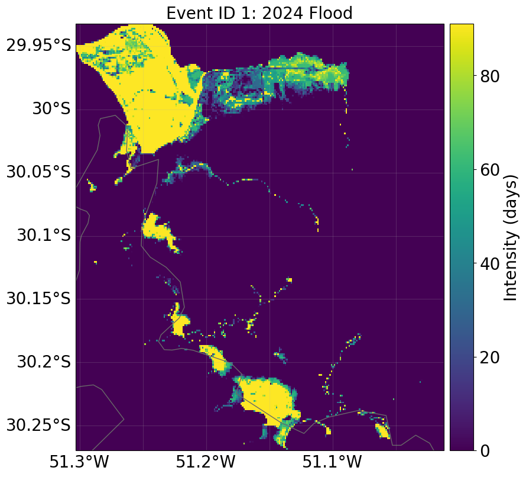

png

```python
%matplotlib inline
from matplotlib import pyplot as plt

# Plot the hazard intensities (this takes a long time and the plots below are more informative):
_ = haz.plot_intensity(event=1)         # event = 1 plots the first (and only) event
```

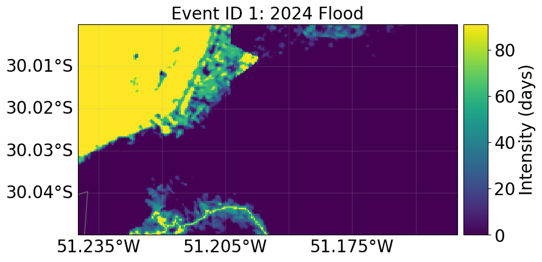

png

```python
# Let's zoom in and plot some smaller areas:

sample_region = (-51.24, -51.15, -30.05, -30.00)  # (min_lon, max_lon, min_lat, max_lat)
lon_min, lon_max, lat_min, lat_max = sample_region

haz_sample = copy.deepcopy(haz)
haz_sample = haz_sample.select(extent=sample_region)

_ = haz_sample.plot_intensity(event=1)
```